# 271 Notebook

2023-01-06

# Bernoulli Distribution

### PMF

$$P(Y=y) = \pi^y(1-\pi)^{1-\pi}$$

```r
dbinom ( x = 1 , size = 5 , prob = 0.6) #PMF / Probability of getting only 1 success
```

```
## [1] 0.0768
```

```r
dbinom ( x = 0:5 , size = 5 , prob = 0.6) #0 - 5 PMF/Probability of successes
```

```
## [1] 0.01024 0.07680 0.23040 0.34560 0.25920 0.07776
```

```r
pmf <- dbinom ( x = 0:5 , size = 5 , prob = 0.6)
save <- data.frame ( w = 0:5 , prob = round( x = pmf , digits = 4) ) #Setting up for plotting
save
```

```
##   w   prob
## 1 0 0.0102
## 2 1 0.0768
## 3 2 0.2304
## 4 3 0.3456
## 5 4 0.2592
## 6 5 0.0778
```

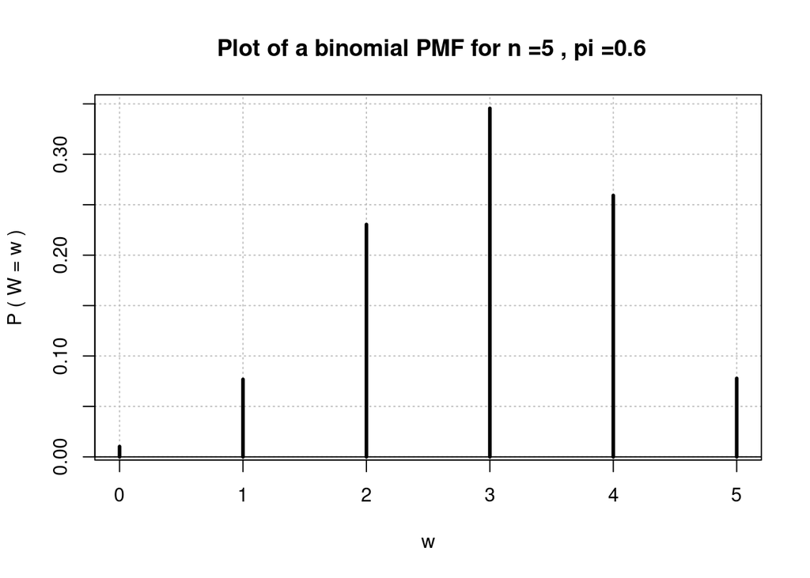

```r
 plot (x = save$w , y = save$prob , type = "h" , xlab = " w " , ylab =
" P ( W = w ) " , main = " Plot of a binomial PMF for n =5 , pi =0.6" ,
panel.first = grid ( col = "gray" , lty = "dotted") , lwd = 3)
# type "h" to indicate a bar up to the PMF
abline ( h = 0)
```

## Monte Carlo of Bernoulli Distribution

```r
set.seed (4848)
bin5 <- rbinom ( n = 1000 , size = 5 , prob = 0.6) #Monte Carlo simulation
bin5 [1:11]
```

```
##  [1] 3 2 4 1 3 1 3 3 3 4 3
```

```r
#rbinom differs from dbinom. Rbinom gets the specific amount of successes "w" with a sample size of "size" while dbinom returns the PMF of a particular value
```

# PMF of Binomial R.V.

$$P(W = w) = {n \choose w}\pi^w(1-\pi)^{n-w}$$

### Expectation and Variance of Bernoulli

$$E(W) = n\pi$$

$$Var(W) = n\pi(1-\pi)$$

```r
mean ( bin5 ) #Close to the actual E[Y]
```

```
## [1] 2.991
```

```r
var ( bin5 ) #Close to the actual Var[Y]
```

```
## [1] 1.236155
```

```r
 table ( x = bin5 )
```

```
## x
##   0   1   2   3   4   5
##  12  84 215 362 244  83
```

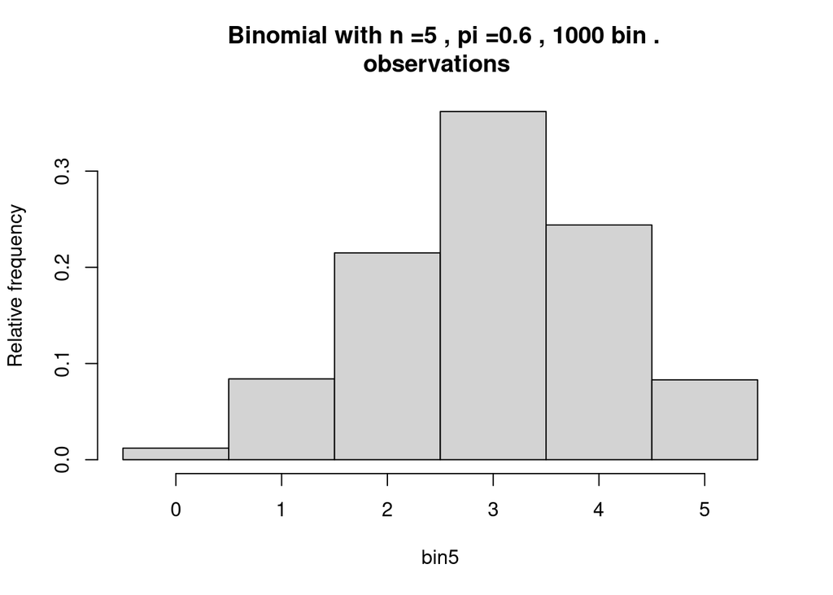

```r
hist ( x = bin5 , main = " Binomial with n =5 , pi =0.6 , 1000 bin .
observations " , probability = TRUE , breaks = c ( -0.5:5.5) , ylab
= " Relative frequency ")
```

```r
#Very similar to the actual PMF
#Probability = TRUE makes the y axis be the relative frequency and not the actual frequency
```

# Maximum Likelihood Estimation and Likelihood Function for Bernoulli

## Likelihood formula when given all results

$$L(\pi|y_1, ...y_n) = P(Y_1 = y_1) \times...\times P(Y_n = y_n) =
\pi^w(1-\pi)^{n-w}$$

## Likelihood formula when given only successes

$$L(\pi|w) = P(W = w) = {n\choose w}\pi^w(1-\pi)^{n-w}$$

## MLE of Bernoulli

$$\hat{\pi} = w/n$$

## Likelihood ratio test

$$\Lambda =
\frac{MLE \; under \; H_0}{MLE\; under\; H_0 \; or \; H_A}$$

Then you gotta do log and stuff to it but it’s hard to write. But you do so to fit it to a chisquare distribution. Used to perform hypothesis test with more than one parameter of interest.

# Wald’s Confidence Interval

$$\hat{\pi} - Z_{1-a/2}\sqrt{\hat{\pi}(1-\hat{\pi})/n} < \pi <
\hat{\pi} + Z_{1-a/2}\sqrt{\hat{\pi}(1-\hat{\pi})/n}$$

Suppose w = 4 out of n = 10 trials. The 95% Wald confidence interval for $\Pi$ is

```r
w <- 4
n <- 10
alpha <- 0.05
pi.hat <- w/n
var.wald <- pi.hat * (1 - pi.hat) / n

lower <- pi.hat - qnorm(p = 1-alpha/2) * sqrt(var.wald)
upper <- pi.hat + qnorm(p = 1-alpha/2) * sqrt(var.wald)
round(data.frame(lower, upper), 4)
```

```
##    lower  upper
## 1 0.0964 0.7036
```

```r
#OR

round(pi.hat + qnorm(p = c(alpha/2, 1-alpha/2)) * sqrt(var.wald), 4)
```

```
## [1] 0.0964 0.7036
```

## Wilson and Agresti-Coull intervals

##### Use Wilson when n < 40

$$\tilde{\pi} = \frac{w+Z_{1-a/2}^2/2}
{n+Z_{1-a/2}^2}$$

$$\tilde{\pi} \pm \frac{w+Z_{1-a/2}\sqrt{n}}
{n+Z_{1-a/2}^2}\sqrt{\tilde{\pi}(1-\tilde{\pi}) + Z^2_{1-a/2}/4n}$$

##### Use Agresti-Coull when n >= 40

$$\tilde{\pi} -
Z_{1-a/2}\sqrt{\frac{\tilde{\pi}(1-\tilde{\pi})}{n+Z^2_{1-a/2}}} <
\pi <
\tilde{\pi} +
Z_{1-a/2}\sqrt{\frac{\tilde{\pi}(1-\tilde{\pi})}{n+Z^2_{1-a/2}}}$$

```r
#estimated pi
p.tilde <- (w + qnorm(p = 1-alpha/2)^2 / 2) / (n + qnorm(p = 1-alpha/2)^2)
p.tilde
```

```
## [1] 0.4277533
```

```r
# Wilson C.I.
round(p.tilde + qnorm(p = c(alpha/2, 1-alpha/2)) * sqrt(n) / (n + qnorm(p = 1-alpha/2)^2) * sqrt(pi.hat*(1-pi.hat) + qnorm(p = 1-alpha/2)^2/(4*n)), 4)
```

```
## [1] 0.1682 0.6873
```

```r
#OR
wilson.ci(4, n = 10, conf.level = 0.95)
```

```
## [1] 0.1693466 0.6877963
## attr(,"conf.level")
## [1] 0.95
```

```r
# Agresti - Coull C.I.
var.ac <- p.tilde *(1 - p.tilde ) / ( n + qnorm ( p = 1 - alpha /2) ^2)
round ( p.tilde + qnorm ( p = c ( alpha /2 , 1 - alpha /2) ) *
sqrt ( var.ac ) , 4)
```

```
## [1] 0.1671 0.6884
```

# Convenient Cheat Code for Calculating CI from All Methods

```r
binom.confint(x = w, n = n, conf.level = 1-alpha, methods = 'all')
```

```
##           method x  n      mean      lower     upper
## 1  agresti-coull 4 10 0.4000000 0.16711063 0.6883959
## 2     asymptotic 4 10 0.4000000 0.09636369 0.7036363
## 3          bayes 4 10 0.4090909 0.14256735 0.6838697
## 4        cloglog 4 10 0.4000000 0.12269317 0.6702046
## 5          exact 4 10 0.4000000 0.12155226 0.7376219
## 6          logit 4 10 0.4000000 0.15834201 0.7025951
## 7         probit 4 10 0.4000000 0.14933907 0.7028372
## 8        profile 4 10 0.4000000 0.14570633 0.6999845
## 9            lrt 4 10 0.4000000 0.14564246 0.7000216
## 10     prop.test 4 10 0.4000000 0.13693056 0.7263303
## 11        wilson 4 10 0.4000000 0.16818033 0.6873262
```

# Finding the True Confidence Level for Wald Interval

n = 40, pi = 0.157, alpha = 0.05

```r
pi <- 0.157 #changing this will change the true CI
alpha <- 0.05
n <- 40 #Changing this will also change the CI
w <- 0:n
pi.hat <- w/n
pmf <- dbinom(x = w, size =n, prob = pi) #Probability of each possible w

#Calculating the 95% wald interval for each possible valeus of w
var.wald <- pi.hat*(1-pi.hat) / n
lower <- pi.hat - qnorm ( p = 1 - alpha /2) * sqrt ( var.wald )
upper <- pi.hat + qnorm ( p = 1 - alpha /2) * sqrt ( var.wald )
save <- ifelse(test = pi >lower, yes = ifelse(test = pi<upper, yes = 1, no = 0), no = 0)
data.frame(w, pi.hat, round(data.frame(pmf, lower, upper), 4), save)[1:13,]
```

```
##     w pi.hat    pmf   lower  upper save
## 1   0  0.000 0.0011  0.0000 0.0000    0
## 2   1  0.025 0.0080 -0.0234 0.0734    0
## 3   2  0.050 0.0292 -0.0175 0.1175    0
## 4   3  0.075 0.0689 -0.0066 0.1566    0
## 5   4  0.100 0.1187  0.0070 0.1930    1
## 6   5  0.125 0.1591  0.0225 0.2275    1
## 7   6  0.150 0.1729  0.0393 0.2607    1
## 8   7  0.175 0.1564  0.0572 0.2928    1
## 9   8  0.200 0.1201  0.0760 0.3240    1
## 10  9  0.225 0.0795  0.0956 0.3544    1
## 11 10  0.250 0.0459  0.1158 0.3842    1
## 12 11  0.275 0.0233  0.1366 0.4134    1
## 13 12  0.300 0.0105  0.1580 0.4420    0
```

```r
#Basically, our proposed 95% Wald CI actually has an 87.5% CI. The probability that a binomial RV is between 4 and 11 with n = 40 and pi = 0.157 is 0.8759
sum ( save * pmf )
```

```
## [1] 0.875905
```

```r
sum ( dbinom ( x = 4:11 , size = n , prob = pi ))
```

```
## [1] 0.875905
```

## Estimated True Confidence Level for Wald Interval with Monte Carlo

n = 40, pi = 0.157, alpha = 0.05

```r
 numb.bin.samples <- 1000 # Binomial samples of size

set.seed (4516)
w <- rbinom (n = numb.bin.samples , size = n , prob = pi ) #creating a bunch of binomial distributions

pi.hat <- w/n

#Calculating the 95% wald interval from each generated binomial distribution and their respective pi.hat
var.wald <- pi.hat*(1-pi.hat) / n
lower <- pi.hat - qnorm ( p = 1 - alpha /2) * sqrt ( var.wald )
upper <- pi.hat + qnorm ( p = 1 - alpha /2) * sqrt ( var.wald )
data.frame (w, pi.hat, lower , upper ) [1:10 ,]
```

```
##    w pi.hat        lower     upper
## 1  6  0.150  0.039344453 0.2606555
## 2  6  0.150  0.039344453 0.2606555
## 3  7  0.175  0.057249138 0.2927509
## 4  8  0.200  0.076040994 0.3239590
## 5  8  0.200  0.076040994 0.3239590
## 6  6  0.150  0.039344453 0.2606555
## 7  8  0.200  0.076040994 0.3239590
## 8  3  0.075 -0.006624323 0.1566243
## 9  5  0.125  0.022511030 0.2274890
## 10 4  0.100  0.007030745 0.1929693
```

```r
save <- ifelse ( test = pi > lower , yes = ifelse ( test = pi < upper ,
yes = 1 , no = 0) , no = 0)

save [1:10]
```

```
##  [1] 1 1 1 1 1 1 1 0 1 1
```

```r
mean ( save )
```

```
## [1] 0.878
```

```r
counts <- table(w)
counts
```

```
## w
##   1   2   3   4   5   6   7   8   9  10  11  12  13
##   8  35  64 123 147 165 172 123  76  46  26  11   4
```

```r
sum(counts[4:11]) / numb.bin.samples #same thing including 1 / all
```

```
## [1] 0.878
```

#### True confidence level plot

n = 40, a = 0.05

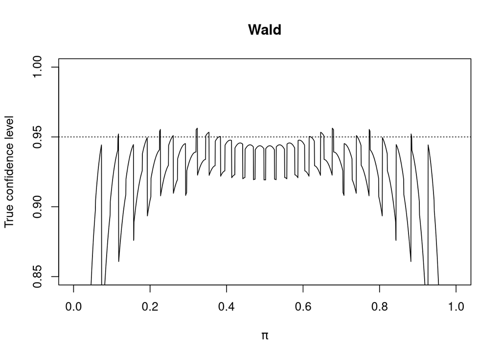

```r
alpha <- 0.05
n <- 40
w <- 0:n
pi.hat <- w/n
pi.seq <- seq ( from = 0.001 , to = 0.999 , by = 0.0005)

#Wald
var.wald <- pi.hat *(1 - pi.hat ) / n
lower.wald <- pi.hat - qnorm (p = 1 - alpha /2) * sqrt ( var.wald )
upper.wald <- pi.hat + qnorm (p = 1 - alpha /2) * sqrt ( var.wald )

# Save true confidence levels in a matrix
save.true.conf <- matrix ( data = NA , nrow = length ( pi.seq ) , ncol
= 2)

# Create counter for the loop
counter <- 1

# Loop over each pi
for ( pi in pi.seq ) {
pmf <- dbinom ( x = w , size = n , prob = pi )
save.wald <- ifelse ( test = pi > lower.wald , yes = ifelse ( test =
pi < upper.wald , yes = 1 , no = 0) , no = 0)
wald <- sum ( save.wald * pmf )
save.true.conf [ counter , ] <- c ( pi , wald )
# print ( save.true.conf [counter ,])
counter <- counter +1
}

plot ( x = save.true.conf [ ,1] , y = save.true.conf [ ,2] , main =
"Wald" , xlab = expression ( pi ) , ylab = " True confidence level " ,
type = "l" , ylim = c (0.85 ,1) )

abline ( h = 1 - alpha , lty ='dotted')
```

# 1.2 Two Binary Variables

## Simulating counts in a contingency table

𝞹1 = 0.2, pi2 = 0.4, n1 = 10, n2 = 10

```r
pi1 <- 0.2
pi2 <- 0.4
n1 <- 10
n2 <- 10

set.seed(8191)
w1 <- rbinom(n = 1, size = n1, prob = pi1) #rbinom returns the actual result
w2 <- rbinom(n = 1, size = n2, prob = pi2)

c.table <- array(data = c(w1, w2, n1-w1, n2-w2), dim = c(2,2),
                 dimnames = list(Group = c(1,2), Response = c(1,2)))
c.table
```

```
##      Response
## Group 1 2
##     1 1 9
##     2 3 7
```

```r
c.table[1,1] #w1
```

```
## [1] 1
```

```r
c.table[1,2] #n1 - w1
```

```
## [1] 9
```

```r
c.table[1,] #w1 and n1-w1
```

```
## 1 2
## 1 9
```

```r
sum(c.table[1,]) #n1
```

```
## [1] 10
```

Lets say we already have the count values for a two-way contingency table

```r
c.table <- array(data = c(251, 48, 34, 5), dim = c(2,2),
                 dimnames = list(First = c('made', 'missed'), Second =
                                   c('made', 'missed')))
c.table
```

```
##         Second
## First    made missed
##   made    251     34
##   missed   48      5
```

```r
#Now to estimate probability of success for each group
rowSums(c.table) # n1 and n2
```

```
##   made missed
##    285     53
```

```r
pi.hat.table <- c.table/rowSums(c.table)
pi.hat.table
```

```
##         Second
## First         made     missed
##   made   0.8807018 0.11929825
##   missed 0.9056604 0.09433962
```

^ This is just a sample of Larry Bird’s free throws. We want to generalize the population of all free throw attempts by Larry Bird.

To do so, we have to infer the difference of the success rates between these groups through confidence intervals

```r
alpha <- 0.05
pi.hat1 <- pi.hat.table[1,1]
pi.hat2 <- pi.hat.table[2,1]

#Wald
var.wald <- pi.hat1*(1-pi.hat1) / sum(c.table[1,]) +
  pi.hat2*(1-pi.hat2) / sum(c.table[2,])

pi.hat1 - pi.hat2 + qnorm(p = c(alpha/2, 1-alpha/2))*(sqrt(var.wald))
```

```
## [1] -0.11218742  0.06227017
```

```r
# Agresti-Caffo
pi.tilde1 <- (c.table[1,1] + 1) / (sum(c.table[1,]) + 2)
pi.tilde2 <- (c.table[2, 1] + 1) /(sum(c.table[2,]) + 2)

var.AC <- pi.tilde1 *(1 - pi.tilde1 ) / ( sum ( c.table [1 ,]) + 2) +
  pi.tilde2 *(1 - pi.tilde2 ) / ( sum ( c.table [2 ,]) + 2)

pi.tilde1 - pi.tilde2 + qnorm ( p = c ( alpha /2 , 1 - alpha /2) ) *sqrt(var.AC)
```

```
## [1] -0.10353254  0.07781192
```